# 成為初級資料分析師 | Python 機器學習

> 梯度遞減（Gradient Descent）

## 郭耀仁

## 大綱

- 關於梯度遞減
- 計算複雜性
- 進階的梯度遞減

## 關於梯度遞減

## 我們目前已經會使用兩種方法在給定 $h = Xw$ 的前提之下，尋找最佳的 $w$

- `sklearn.linear_model` 的 `LinearRegression()` 或 `Ridge()`
- 自行撰寫正規方程（normal equations），包含無正規化效果以及有正規化效果的

## 除了前述這兩種方法以外，還有第三種方法稱為梯度遞減（Gradient Descent），同樣能夠在給定 $h = Xw$ 的前提之下，尋找最佳的 $w$

## 什麼是梯度遞減？

> 梯度遞減是一種透過「迭代」實踐最佳化的演算法，利用一組隨機賦予的 $w$ 作為起始，計算該點每個 $w_i$ 對成本函數偏微分的斜率，並依照偏微分斜率的正負值與學習速率，決定目前的 $w$ 應該減少或者增加多少，在適當的學習速率設定下，經過足夠次數的迭代後可以得到一組逼近成本函數最小的係數組合 $w$。

## 讓我們先將 $h$ 簡化為只有 $w_1$：

$$h(x_1) = w_1x_1$$

## 給定一組 $x_1$ 與 $y$

```python
print(x_1)
print(y)
```

```
[ 1  2  3  4  5  6  7  8  9 10]
[ 3  6  9 12 15 18 21 24 27 30]
```

## 假設我們看不出來 $w_1 =3$

## 所以在 1 到 5 之間窮舉了 100 個 $w_1$，將每個 $w_1$ 帶入成本函數 MSE 中計算

$$MSE_{train} = \frac{1}{m}\sum_i(\hat{y}^{(train)} - y^{(train)})_i^2$$

```python
x_1 = np.arange(1, 11)
y = np.arange(3, 33, 3)
m = y.size
w_1_arr = np.linspace(1, 5, 100)
mses = []
for i in w_1_arr:
    y_hat = x_1*i
    mse = (((y_hat - y)**2).sum())/m
    mses.append(mse)
```

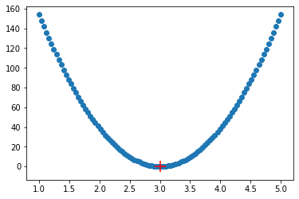

```python
%matplotlib inline
import matplotlib.pyplot as plt

fig = plt.figure()
ax = plt.axes()
ax.scatter(w_1_arr, mses)
ax.scatter(3, 0, marker="+", s=200, c="r")
plt.show()
```

## 在我們窮舉的 100 個 $w_1$ 之中第 49 個 $w_1$ 能夠讓 MSE 最低

```python
min_index = mses.index(min(mses))
print(min_index)
print(w_1_arr[min_index])
```

```
49
2.97979797979798
```

## 這個做法是對的嗎？

## 不過是運氣好在一個有包含 $w_1 = 3$ 的區間窮舉而已，假如在其他區間窮舉 100 個 $w_1$，像是 5 到 9

```python
x_1 = np.arange(1, 11)
y = np.arange(3, 33, 3)
m = y.size
w_1_arr = np.linspace(5, 9, 100)
mses = []
for i in w_1_arr:
    y_hat = x_1*i
    mse = (((y_hat - y)**2).sum())/m
    mses.append(mse)
```

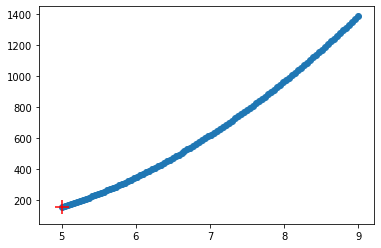

```python
fig = plt.figure()
ax = plt.axes()
ax.scatter(w_1_arr, mses)
y_hat = x_1*5
mse = (((y_hat - y)**2).sum())/m
ax.scatter(5, mse, marker="+", s=200, c="r")
plt.show()
```

## 在我們窮舉的 100 個 $w_1$ 之中第 0 個 $w_1$ 能夠讓 MSE 最低，但並不是理想中的 $w_1 = 3$

```python
min_index = mses.index(min(mses))
print(min_index)
print(w_1_arr[min_index])
```

```
0
5.0
```

## 梯度遞減的演算法就是為了因應這樣窮舉式、大海撈針式的找 $w_1$ 方法

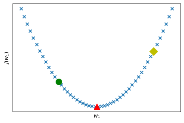

```python
get_gd_plot()
```

## 何謂有意識地、在窮舉的 $w_1$ 中向正確的方向修正？

- $w_1$ 位於綠圓點，$\frac{\mathrm \partial}{\mathrm \partial w_1} J(w_1)$ 為負值，$w_1$ 應該要向右邊修正
- $w_1$ 位於黃方塊，$\frac{\mathrm \partial}{\mathrm \partial w_1} J(w_1)$ 為正值，$w_1$ 應該要向左邊修正
- $w_1$ 位於紅三角，$\frac{\mathrm \partial}{\mathrm \partial w_1} J(w_1)$ 為零，$w_1$ 應該要停止修正，收斂

## 第三種找出 $w$ 的方法：梯度遞減（Gradient Descent）指的就是從隨機指定的 $w_1$ 起始透過迭代、有意識地朝 $w_1^*$ 修正、更新

$$ w_1 := w_1 - \alpha \frac{\mathrm \partial}{\mathrm \partial w_1} J(w_1) \\ $$

## $w_1$ 修正的速度與 $\alpha$ 相關，$\alpha$ 稱為學習速率（Learning Rate）

## 有意識地向正確方向修正特定幅度

- $w_1$ 位於綠圓點，$\frac{\mathrm \partial}{\mathrm \partial w_1} J(w_1)$ 為負值，$w_1$ 向右邊修正 $\alpha \frac{\mathrm \partial}{\mathrm \partial w_1} J(w_1)$
- $w_1$ 位於黃方塊，$\frac{\mathrm \partial}{\mathrm \partial w_1} J(w_1)$ 為正值，$w_1$ 向左邊修正 $\alpha \frac{\mathrm \partial}{\mathrm \partial w_1} J(w_1)$
- $w_1$ 位於紅三角，$\frac{\mathrm \partial}{\mathrm \partial w_1} J(w_1)$ 為零，$w_1$ 要停止修正，收斂

## 如何挑選學習速率

- 如果學習速率夠小，成本函數每一次都會下降
- 學習速率太小，收斂的速度太慢
- 學習速率太大，可能會無法收斂

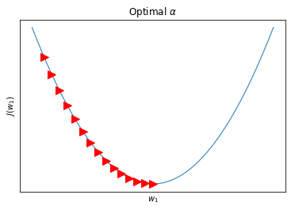

```python
get_optimal_alpha_plot()
```

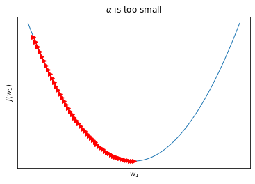

```python
get_small_alpha_plot()
```

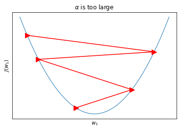

```python
get_large_alpha_plot()
```

## 推導對 $w_1$ 偏微分的成本函數（梯度）

$$ J(w_1) = \frac{1}{m}\sum_i (\hat{y} - y)_i^2 = \frac{1}{m}\sum_i (w_1x_{i1} - y_i)^2 \\ J(w_1) = \frac{1}{m}\sum_i (w_1^2x_{i1}^2-2w_1x_{i1}y_i+y_i^2) \\ \frac{\partial J}{\partial w_1} = \frac{1}{m}\sum_i(2w_1x_{i1}^2 - 2x_{i1}y_i) \\ \frac{\partial J}{\partial w_1} = \frac{2}{m}\sum_i(w_1x_{i1}^2 - x_{i1}y_i) = \frac{2}{m}\sum_i x_{i1}(x_{i1}w_1 - y_i) $$

## 梯度遞減（Gradient Descent）：從隨機指定的 $w_1$ 起始透過迭代、有意識地朝 $w_1^*$ 修正、更新

$$ w_1 := w_1 - \alpha \frac{\mathrm \partial}{\mathrm \partial w_1} J(w_1) \\ w_1 := w_1 - \alpha \frac{2}{m}\sum_i x_{i1}(x_{i1}w_1 - y_i) \\ w_1 := w_1 - \alpha \frac{2}{m}\sum_i x_{i1}(\hat{y_i} - y_i) $$

## 給定 $x_1$ 與 $y$，根據梯度遞減（Gradient Descent）的演算法，利用 1000 次的迭代、$\alpha = 0.0001$ 找出 $w_1$

$$h(x_1) = w_1x_1$$

```python
x_1 = np.arange(1, 11)
y = np.arange(3, 33, 3)
```

```python
def get_grad(X, y, w_1):
    m = y.size
    y_hat = w_1*X
    err = y_hat - y
    grad = (X*(err)).sum()*2/m
    return grad

w_1 = np.random.random(1)[0]
learning_rate = 0.0001
for i in range(1000):
    grad = get_grad(x_1, y, w_1)
    w_1 -= learning_rate*grad
    if i % 100 == 0:
        print("{} iterations: w_1 = {}".format(i, w_1))
```

```
0 iterations: w_1 = 0.9226019232627077
100 iterations: w_1 = 2.040999440027331
200 iterations: w_1 = 2.5572913615707584
300 iterations: w_1 = 2.795630006154054
400 iterations: w_1 = 2.9056555694671236
500 iterations: w_1 = 2.9564472679913942
600 iterations: w_1 = 2.9798945157154515
700 iterations: w_1 = 2.9907185960633575
800 iterations: w_1 = 2.9957153750779657
900 iterations: w_1 = 2.998022065320309
```

```python
print(w_1)
```

```
2.9990798299590415
```

## 承接上題，將迭代過程的成本（MSE）記錄起來並作圖

```python
def get_mse(X, y, w_1):
    m = y.size
    err = w_1*X - y
    se = err**2
    sse = se.sum()
    mse = sse / m
    return mse

def get_grad(X, y, w_1):
    m = y.size
    y_hat = w_1*X
    err = y_hat - y
    grad = (X*(err)).sum()*2/m
    return grad

w_1 = np.random.random(1)[0]
learning_rate = 0.0001
j_history = []
w_1_history = []
for i in range(1000):
    grad = get_grad(x_1, y, w_1)
    mse = get_mse(x_1, y, w_1)
    j_history.append(mse)
    w_1 -= learning_rate*grad
    if i % 100 == 0:
        print("{} iterations: w_1 = {}".format(i, w_1))
        w_1_history.append(w_1)
```

```
0 iterations: w_1 = 0.9245708520830301
100 iterations: w_1 = 2.0419083673351883
200 iterations: w_1 = 2.557710954621782
300 iterations: w_1 = 2.795823705173706
400 iterations: w_1 = 2.905744987797868
500 iterations: w_1 = 2.9564885466611974
600 iterations: w_1 = 2.9799135714120473
700 iterations: w_1 = 2.9907273928480995
800 iterations: w_1 = 2.995719435985497
900 iterations: w_1 = 2.9980239399791144
```

```python
print(j_history[:20])
```

```
[168.41880067865844, 165.83513669889936, 163.29110795899118, 160.7861064262136, 158.31953339549992, 155.89079934634424, 153.49932380190378, 151.1445351902627, 148.82587070782407, 146.54277618479784, 144.29470595275194, 142.0811227141955, 139.9014974141626, 137.75530911376623, 135.64204486569156, 133…
```

```python
def get_gd_plots(j_history, w_1_history):
    fig, axes = plt.subplots(1, 2, figsize=(13, 3))
    axes[0].plot(range(len(j_history)), j_history)
    axes[0].set_xlabel("Number of iterations")
    axes[0].set_ylabel("MSE")
    axes[0].set_title("MSE trend")
    axes[1].scatter([i*100 for i in range(len(w_1_history))], w_1_history, marker="+")
    axes[1].scatter(0, w_1_history[0], marker="+", s=150, color="green")
    axes[1].scatter(len(w_1_history)-1, w_1_history[-1], marker="+", s=150, color="red")
    axes[1].set_xlabel("Number of iterations")
    axes[1].set_ylabel("$w_1$")
    axes[1].set_title("How does $w_1$ converge")
    plt.show()
```

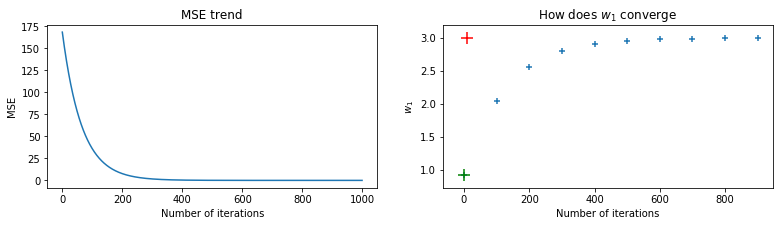

```python
get_gd_plots(j_history, w_1_history)
```

## 接著讓我們將 $w_0$ 加回先前簡化只有 $w_1$ 的 $h$ 之中：

$$h(x_0, x_1) = w_0x_0 + w_1x_1 \text{, where } x_0 = 1$$

## 給定 $x_0$、$x_1$ 與 $y$

```python
print(x_0)
print(x_1)
print(y)
```

```
[1 1 1 1 1 1 1 1 1 1]
[ 1  2  3  4  5  6  7  8  9 10]
[11 17 23 29 35 41 47 53 59 65]
```

## 假設我們看不出來 $w_0=5$ $w_1 =6$

## 透過先前的經驗，我們知道可以利用梯度遞減求 $w_0$ 與 $w_1$

$$ w_0 := w_0 - \alpha \frac{\mathrm \partial}{\mathrm \partial w_0} J(w_0, w_1) \\ w_1 := w_1 - \alpha \frac{\mathrm \partial}{\mathrm \partial w_1} J(w_0, w_1) $$

## 推導對 $w_0$ 與 $w_1$ 偏微分的成本函數（梯度）

$$ J(w_0, w_1) = \frac{1}{m}\sum_i(\hat{y_i} - y_i)^2 = \frac{1}{m}\sum_i(w_0 + w_1x_{i1} - y_i)^2 \\ J(w_0, w_1) = \frac{1}{m}\sum_i\big((w_0 + w_1x_{i1})^2-2(w_0 + w_1x_{i1})y_i+y_i^2\big) \\ J(w_0, w_1) = \frac{1}{m}\sum_i\big(w_0^2+2w_0w_1x_{i1}+w_1^2x_{i1}^2-2(w_0 + w_1x_{i1})y_i+y_i^2\big) \\ \frac{\partial J}{\partial w_0} = \frac{1}{m}\sum_i(2w_0+2w_1x_{i1}-2y_i) = \frac{2}{m}\sum_i(w_0+w_1x_{i1}-y_i) \\ \frac{\partial J}{\partial w_1} = \frac{1}{m}\sum_i(2w_0x_{i1}+2w_1x_{i1}^2-2x_{i1}y_i) = \frac{2}{m}\sum_i(w_0x_{i1}+w_1x_{i1}^2-x_{i1}y_i) = \frac{2}{m}\sum_i x_{i1}(w_0+w_1x_{i1}-y_i) \\ $$

## 梯度遞減（Gradient Descent）：從隨機指定的 $(w_0, w_1)$ 起始透過迭代、有意識地朝 $(w_0^*, w_1^*)$ 修正、更新

$$ w_0 := w_0 - \alpha \frac{\mathrm \partial}{\mathrm \partial w_0} J(w_0, w_1) = w_0 - \alpha \frac{2}{m}\sum_i (w_0+w_1x_{i1}-y_i) = w_0 - \alpha \frac{2}{m}\sum_i (\hat{y_i}-y_i)\\ w_1 := w_1 - \alpha \frac{\mathrm \partial}{\mathrm \partial w_1} J(w_0, w_1) = w_1 - \alpha \frac{2}{m}\sum_i x_{i1}(w_0+w_1x_{i1}-y_i) = w_1 - \alpha \frac{2}{m}\sum_i x_{i1}(\hat{y_i}-y_i)\\ $$

## 給定 $x_0$、$x_1$ 與 $y$，根據梯度遞減（Gradient Descent）的演算法，利用 200000 次的迭代、$\alpha = 0.0001$ 找出 $(w_0, w_1)$

$$h(x_0, x_1) = w_0x_0 + w_1x_1 \text{ , where} x_0 = 1$$

```python
print(x_0)
print(x_1)
print(y)
```

```
[1 1 1 1 1 1 1 1 1 1]
[ 1  2  3  4  5  6  7  8  9 10]
[11 17 23 29 35 41 47 53 59 65]
```

```python
def get_grad(x_1, y, w_1, w_0):
    m = y.size
    y_hat = w_0 + w_1*x_1
    err = y_hat - y
    grad_0 = err.sum()*2/m
    grad_1 = ((x_1*err).sum())*2/m
    return grad_0, grad_1

w_0, w_1 = np.random.random(2)
learning_rate = 0.0001
for i in range(200000):
    grad_0, grad_1 = get_grad(x_1, y, w_1, w_0)
    w_0 -= learning_rate*grad_0
    w_1 -= learning_rate*grad_1
    if i % 5000 == 0:
        print("{} iterations: w_0 = {}; w_1 = {}".format(i, w_0, w_1))
```

```
0 iterations: w_0 = 0.47903461109126233; w_1 = 0.4370605309888606
5000 iterations: w_0 = 2.044018546653757; w_1 = 6.424598804257884
10000 iterations: w_0 = 2.603883386032601; w_1 = 6.3441795103285585
15000 iterations: w_0 = 3.0577094551012114; w_1 = 6.278991683777939
20000 iterations: w_0 = 3.4255805669837907; w_1 = 6.2261504746257135
25000 iterations: w_0 = 3.7237766473356273; w_1 = 6.183317425382983
30000 iterations: w_0 = 3.965494193141651; w_1 = 6.148596983953554
35000 iterations: w_0 = 4.161430276142997; w_1 = 6.1204526170600575
40000 iterations: w_0 = 4.3202559356286665; w_1 = 6.09763881184259
45000 iterations: w_0 = 4.448999910320105; w_1 = 6.079145956399432
50000 iterations: w_0 = 4.5533596911831244; w_1 = 6.064155659989795
55000 iterations: w_0 = 4.637953660632023; w_1 = 6.052004535619658
60000 iterations: w_0 = 4.706525476401893; w_1 = 6.042154842229764
65000 iterations: w_0 = 4.76210974498046; w_1 = 6.034170687272602
70000 iterations: w_0 = 4.807166316382685; w_1 = 6.02769873653702
```

[output cut: 25 more lines]

```python
print(w_0)
print(w_1)
```

```
4.999179339517062
6.00011788012383
```

## 承接上題，將迭代過程的成本（MSE）記錄起來並作圖

```python
def get_mse(x_1, y, w_1, w_0):
    m = y.size
    err = w_0 + w_1*x_1 - y
    se = err**2
    sse = se.sum()
    mse = sse / m
    return mse

def get_grad(x_1, y, w_1, w_0):
    m = y.size
    y_hat = w_0 + w_1*x_1
    err = y_hat - y
    grad_0 = err.sum()*2/m
    grad_1 = ((x_1*err).sum())*2/m
    return grad_0, grad_1

w_0, w_1 = np.random.random(2)
learning_rate = 0.0001
j_history = []
w_0_history = []
w_1_history = []
for i in range(200000):
    grad_0, grad_1 = get_grad(x_1, y, w_1, w_0)
    mse = get_mse(x_1, y, w_1, w_0)
    j_history.append(mse)
    w_0 -= learning_rate*grad_0
    w_1 -= learning_rate*grad_1
    if i % 5000 == 0:
        print("{} iterations: w_0 = {}; w_1 = {}".format(i, w_0, w_1))
        w_0_history.append(w_0)
        w_1_history.append(w_1)
```

```
0 iterations: w_0 = 0.4340428914456634; w_1 = 0.763987439628519
5000 iterations: w_0 = 1.9709893574706885; w_1 = 6.435088757220191
10000 iterations: w_0 = 2.5446859735089022; w_1 = 6.352682659272294
15000 iterations: w_0 = 3.0097240716031624; w_1 = 6.285884330696288
20000 iterations: w_0 = 3.386683646809594; w_1 = 6.231737649665863
25000 iterations: w_0 = 3.692246829529736; w_1 = 6.187846385780786
30000 iterations: w_0 = 3.939936143650326; w_1 = 6.152268156261111
35000 iterations: w_0 = 4.140712938103707; w_1 = 6.123428466908143
40000 iterations: w_0 = 4.303462475095674; w_1 = 6.1000510337642115
45000 iterations: w_0 = 4.435387142302375; w_1 = 6.081101301896077
50000 iterations: w_0 = 4.54232519041775; w_1 = 6.065740661758073
55000 iterations: w_0 = 4.6290091015987285; w_1 = 6.053289337006297
60000 iterations: w_0 = 4.699275022756419; w_1 = 6.0431963013853
65000 iterations: w_0 = 4.756232532043633; w_1 = 6.035014893376302
70000 iterations: w_0 = 4.802402251457373; w_1 = 6.028383049447174
```

[output cut: 25 more lines]

```python
print(j_history[:20])
```

```
[1360.5912741463492, 1339.33882078891, 1318.4190549690163, 1297.8267687094612, 1277.5568355600712, 1257.6042093214623, 1237.9639227887724, 1218.6310865150608, 1199.600887594065, 1180.8685884620131, 1162.429525718193, 1144.279108963984, 1126.4128196600643, 1108.8262100015047, 1091.5149018104755, 1074…
```

```python
def get_gd_plots(j_history, w_0_history, w_1_history):
    fig, axes = plt.subplots(1, 2, figsize=(13, 3))
    axes[0].plot(range(len(j_history)), j_history)
    axes[0].set_xlabel("Number of iterations")
    axes[0].set_ylabel("MSE")
    axes[0].set_title("MSE trend")
    axes[1].scatter(w_0_history, w_1_history, marker="+")
    axes[1].scatter(w_0_history[0], w_1_history[0], marker="+", s=150, color="green")
    axes[1].scatter(w_0_history[-1], w_1_history[-1], marker="+", s=150, color="red")
    axes[1].set_xlabel("$w_0$")
    axes[1].set_ylabel("$w_1$")
    axes[1].set_title("How does $w_0$ and $w_1$ converge")
    plt.show()
```

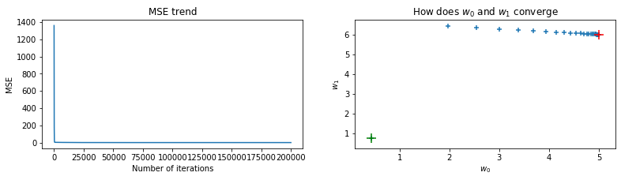

```python
get_gd_plots(j_history, w_0_history, w_1_history)
```

## 最後我們將 $h$ 還原為泛化的外觀：

$$ h(x) = w_0x_0 + w_1x_1 + w_2x_2 + ... + w_nx_n = w^Tx \text{, where } x_0 = 1 \\ h(X) = Xw $$

## 透過先前的經驗，我們知道可以利用梯度遞減求 $w$

$$ w_0 := w_0 - \alpha \frac{\mathrm \partial}{\mathrm \partial w_0} J(w) \\ w_1 := w_1 - \alpha \frac{\mathrm \partial}{\mathrm \partial w_1} J(w) \\ .\\ .\\ .\\ w_n := w_n - \alpha \frac{\mathrm \partial}{\mathrm \partial w_1} J(w) $$

## 利用梯度遞減求 $w$，寫成泛化的外觀：

$$ w_i := w_i - \alpha \frac{\mathrm \partial}{\mathrm \partial w_i} J(w) \\ \text{where } i = 0, 1, 2, ..., n $$

## 推導對 $w_i$ 偏微分的成本函數（梯度）

$$ J(w) = \frac{1}{m}(\hat{y} - y)^T(\hat{y} - y) = \frac{1}{m}(Xw - y)^T(Xw-y) \\ J(w) = \frac{1}{m}(w^TX^T-y^T)(Xw-y) = \frac{1}{m}(w^TX^TXw-w^TX^Ty-y^TXw+y^Ty) = \frac{1}{m}(w^TX^TXw-2w^TX^Ty+y^Ty)\\ \frac{\partial J}{\partial w} = \frac{1}{m}(2X^TXw - 2X^Ty) = \frac{2}{m}(X^T(Xw - y))\\ $$

## 梯度遞減（Gradient Descent）：從隨機指定的 $(w)$ 起始透過迭代、有意識地朝 $(w^*)$ 修正、更新

$$ w := w - \alpha\frac{2}{m}(X^T(Xw - y)) \\ w := w - \alpha\frac{2}{m}(X^T(\hat{y} - y)) $$

## 給定 $x_0$、$x_1$ 與 $y$，根據泛化的梯度遞減（Gradient Descent）演算法，找出 $w$

$$h(x) = Xw \text{ , where} x_0 = 1$$

```python
print(x_0)
print(x_1)
print(y)
```

```
[1 1 1 1 1 1 1 1 1 1]
[0 1 2 3 4 5 6 7 8 9]
[ 5 11 17 23 29 35 41 47 53 59]
```

```python
def get_grad(X, y, w):
    m = y.size
    y_hat = X.dot(w)
    y_reshaped = y.reshape(-1, 1)
    err = y_hat - y_reshaped
    grad = (X.T.dot(err))*2/m
    return grad

X = np.concatenate([x_0.reshape(-1, 1), x_1.reshape(-1, 1)], axis=1)
n = X.shape[1]
w = np.random.rand(n, 1)
learning_rate = 0.0001
for i in range(100000):
    grad = get_grad(X, y, w)
    w -= learning_rate*grad
    if i % 5000 == 0:
        print("{} iterations: w_0 = {}; w_1 = {}".format(i, w[0, 0], w[1, 0]))
```

```
0 iterations: w_0 = 0.5333953538784273; w_1 = 0.21457966507948872
5000 iterations: w_0 = 2.3941380808098884; w_1 = 6.415569132482145
10000 iterations: w_0 = 3.0351973365093445; w_1 = 6.313336379166851
15000 iterations: w_0 = 3.5185517781924402; w_1 = 6.236253558878874
20000 iterations: w_0 = 3.8829978324654006; w_1 = 6.1781336218646095
25000 iterations: w_0 = 4.157787748562248; w_1 = 6.134311573502567
30000 iterations: w_0 = 4.364977529061186; w_1 = 6.101270038681677
35000 iterations: w_0 = 4.521197254125878; w_1 = 6.076356939816443
40000 iterations: w_0 = 4.638985894282299; w_1 = 6.057572627936479
45000 iterations: w_0 = 4.727797750430128; w_1 = 6.043409380934861
50000 iterations: w_0 = 4.7947613029590865; w_1 = 6.032730386308348
55000 iterations: w_0 = 4.845251378966915; w_1 = 6.024678494943321
60000 iterations: w_0 = 4.883320562560011; w_1 = 6.018607422073482
65000 iterations: w_0 = 4.912024475369016; w_1 = 6.014029873256686
70000 iterations: w_0 = 4.933667035906999; w_1 = 6.010578431704373
75000 iterations: w_0 = 4.949985383505018; w_1 = 6.007976067586411
80000 iterations: w_0 = 4.96228930973697; w_1 = 6.006013902241926
85000 iterations: w_0 = 4.971566388792407; w_1 = 6.0045344425412175
90000 iterations: w_0 = 4.9785612450829; w_1 = 6.003418939705443
95000 iterations: w_0 = 4.9838353204930455; w_1 = 6.002577857940253
```

```python
print(w)
```

```
[[4.98781125]
 [6.0019438 ]]
```

## 承接上題，將迭代過程的成本（MSE）記錄起來並作圖

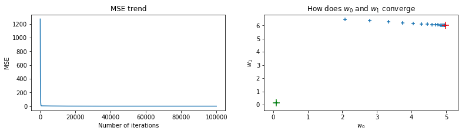

```python
get_gd_plots(j_history, w_0_history, w_1_history)
```

## 隨堂練習：在 NBA 球員資料集上應用梯度遞減求 $w$

```python
from sklearn.model_selection import train_test_split
from sklearn.linear_model import LinearRegression

nba_players = pd.read_csv("https://kaggle-getting-started.s3-ap-northeast-1.amazonaws.com/regression/nba_players.csv")
X = nba_players[["ppg", "rpg", "apg"]].values
y = nba_players["salary"].values
X_train, X_validation, y_train, y_validation = train_test_split(X, y, test_size=0.33, random_state=42)
lr = LinearRegression()
lr.fit(X_train, y_train)
w = lr.coef_.copy()
w = np.insert(w, 0, lr.intercept_).reshape(-1, 1)
print(w)
```

```
[[-3826950.3536627 ]
 [  821082.67478206]
 [  927651.71301024]
 [ 1047513.1335338 ]]
```

```python
from sklearn.preprocessing import PolynomialFeatures

def get_mse(X, y, w):
    m = y.size
    y_hat = X.dot(w)
    y_reshaped = y.reshape(-1, 1)
    err = y_hat - y_reshaped
    se = err**2
    sse = se.sum()
    mse = sse / m
    return mse

def get_grad(X, y, w):
    m = y.size
    y_hat = X.dot(w)
    y_reshaped = y.reshape(-1, 1)
    err = y_hat - y_reshaped
    grad = (X.T.dot(err))*2/m
    return grad

poly = PolynomialFeatures(1)
X_train_poly = poly.fit_transform(X_train)
n = X_train_poly.shape[1]
w = np.random.rand(n, 1)
learning_rate = 0.0001
j_history = []
for i in range(200000):
    mse = get_mse(X_train_poly, y_train, w)
    j_history.append(mse)
    grad = get_grad(X_train_poly, y_train, w)
    w -= learning_rate*grad
    if i % 5000 == 0:
        print("{} iterations: w_0 = {}; w_1 = {}; w_2 = {}; w_3 = {}".format(i, w[0, 0], w[1, 0], w[2, 0], w[3, 0]))
```

```
0 iterations: w_0 = 2114.2749858256484; w_1 = 29743.16643515349; w_2 = 11474.615085602509; w_3 = 6905.393338267257
5000 iterations: w_0 = -637219.1743276436; w_1 = 793871.0473582386; w_2 = 552628.0440378041; w_3 = 729567.3895978649
10000 iterations: w_0 = -1228532.5419611167; w_1 = 766113.8236237875; w_2 = 652396.9795941757; w_3 = 882545.2295899615
15000 iterations: w_0 = -1713724.1837642684; w_1 = 767697.8563933988; w_2 = 711827.7595483635; w_3 = 938182.8617847352
20000 iterations: w_0 = -2109244.2870352506; w_1 = 775391.8611620931; w_2 = 754349.0457825129; w_3 = 965219.0565151587
25000 iterations: w_0 = -2430982.419475836; w_1 = 783341.5226908074; w_2 = 787373.0969261723; w_3 = 982374.2628227165
30000 iterations: w_0 = -2692521.7320530536; w_1 = 790251.2571922463; w_2 = 813803.9765355501; w_3 = 995039.4177429075
35000 iterations: w_0 = -2905077.9721929156; w_1 = 795985.3924949548; w_2 = 835174.9872014282; w_3 = 1004993.5081822688
40000 iterations: w_0 = -3077812.4158713687; w_1 = 800676.6453814533; w_2 = 852513.1447961511; w_3 = 1012992.9221670631
45000 iterations: w_0 = -3218182.211523688; w_1 = 804497.230347691; w_2 = 866595.0153858613; w_3 = 1019469.7237461613
50000 iterations: w_0 = -3332250.522548703; w_1 = 807604.1444597739; w_2 = 878036.2870993575; w_3 = 1024726.6464336386
55000 iterations: w_0 = -3424945.2972398493; w_1 = 810129.4844928865; w_2 = 887333.2116999836; w_3 = 1028996.8842837076
60000 iterations: w_0 = -3500271.3371716216; w_1 = 812181.7921388507; w_2 = 894887.9768032503; w_3 = 1032466.5416580476
65000 iterations: w_0 = -3561483.1021435317; w_1 = 813849.5880091683; w_2 = 901027.1240461102; w_3 = 1035285.9521298886
70000 iterations: w_0 = -3611225.2609660556; w_1 = 815204.8900698248; w_2 = 906015.933347657; w_3 = 1037577.042143788
```

[output cut: 25 more lines]

```python
print(w)
```

```
[[-3825970.74835598]
 [  821055.98381683]
 [  927553.46517735]
 [ 1047468.01387512]]
```

## 已經有了正規方程可以得到 $w^*$ 為什麼還需要梯度遞減？

原因是因為使用正規方程（normal equations）求解，在變數個數增多的時候會遭遇計算複雜性的議題。

## 計算複雜性

## 什麼是計算複雜性？

> 計算複雜性（Computational Complexity）是研究解決問題所需的資源，諸如時間（要通過多少步演算才能解決問題）和空間（在解決問題時需要多少記憶體），在演算法中常見到所謂的大 O 符號就是用來表示演算所需時間資源的表達式。

## 正規方程 normal equations 需要計算 $X^TX$ 的反矩陣

$$w = (X^{(train)T}X^{(train)})^{-1}X^{(train)T}y^{(train)}$$

## 為何計算 $X^TX$ 的反矩陣是在變數個數 $n$ 增多時才有計算複雜性的議題？$m$ 呢？

$X$ 的外觀為 $m \times n$，$X^T$ 的外觀為 $n \times m$，$X^TX$ 的外觀為 $n \times n$

## 計算 $n$ 很大的 $n \times n$ 反矩陣為何會產生計算複雜性議題？

## 這要先將時間拉回到 2005 年

[figure not shown]

Source: https://www.screengeek.net/2019/05/13/avengers-endgame-directors-time-travel/

## 為何是 2005 年？

> NumPy 1.0 was relased in 2006. This new project was part of SciPy.

Source: https://en.wikipedia.org/wiki/NumPy

## 在 Vanilla Python 計算一個 $2 \times 2$ 矩陣 $A$ 的反矩陣其實已經有點辛苦了...

## 計算 $3 \times 3$ 的反矩陣要計算 9 個 $2 \times 2$ 矩陣的行列式（determinant）

[figure not shown]

Source: http://mathworld.wolfram.com/MatrixInverse.html

## 以此類推 $4 \times 4$ 的反矩陣我們要計算 16 個 $3 \times 3$ 矩陣的行列式，$n \times n$ 的反矩陣就要計算 $n^2$ 個 $(n-1) \times (n-1)$ 矩陣的行列式

## `NumPy` 底層還是用 C 語言與 Python 實作，使用封裝好的函數並不代表計算複雜性的問題不存在

## 什麼時候 $n$ 會很大呢？

例如，一張 28 x 28 的圖片，n 就是 784

```python
import pandas as pd

digits = pd.read_csv("https://kaggle-getting-started.s3-ap-northeast-1.amazonaws.com/mnist/train.csv")
def get_y_X(df, target):
    y = df[target].values.reshape(-1, 1)
    X = df.drop(labels=target, axis=1).values
    return y, X
y, X = get_y_X(digits, "label")
print(X.shape[1])
```

```
784
```

## 因此機器學習、深度學習更傾向使用梯度遞減的方法尋找 $w$，而非正規方程

## 進階的梯度遞減

## 給定 Kaggle 資料集 [House Prices: Advanced Regression Techniques](https://www.kaggle.com/c/house-prices-advanced-regression-techniques) 使用 `sklearn.linear_model.LinearRegression` 找出 $w$

```python
import numpy as np
import pandas as pd
from sklearn.model_selection import train_test_split
from sklearn.linear_model import LinearRegression

housing_train = pd.read_csv("https://storage.googleapis.com/kaggle_datasets/House-Prices-Advanced-Regression-Techniques/train.csv")
X = housing_train["GrLivArea"].values.reshape(-1, 1)
y = housing_train["SalePrice"].values
X_train, X_validation, y_train, y_validation = train_test_split(X, y, test_size=0.33, random_state=42)
lr = LinearRegression()
lr.fit(X_train, y_train)
w = lr.coef_.copy()
w = np.insert(w, 0, lr.intercept_).reshape(-1, 1)
print(w)
```

```
[[30774.03773616]
 [   98.50395317]]
```

## 使用 Gradient Descent 找出 $w$

```python
housing_train = pd.read_csv("https://storage.googleapis.com/kaggle_datasets/House-Prices-Advanced-Regression-Techniques/train.csv")
X = housing_train["GrLivArea"].values.reshape(-1, 1)
y = housing_train["SalePrice"].values
poly = PolynomialFeatures(1)
X_poly = poly.fit_transform(X)
X_train, X_validation, y_train, y_validation = train_test_split(X_poly, y, test_size=0.33, random_state=42)
n_epochs = 100000
learning_rate = 0.0000001
w, w_0_history, w_1_history, j_history = gradient_descent(X_train, y_train, n_epochs, learning_rate)
```

```
0 iterations: w_0 = 0.21245020161879646; w_1 = 60.7969180821653
5000 iterations: w_0 = 3.48288388809981; w_1 = 116.55184140076507
10000 iterations: w_0 = 6.72027381898583; w_1 = 116.54994257079908
15000 iterations: w_0 = 9.957323141988281; w_1 = 116.54804394061021
20000 iterations: w_0 = 13.194031892942753; w_1 = 116.54614551017747
25000 iterations: w_0 = 16.430400107680963; w_1 = 116.5442472794798
30000 iterations: w_0 = 19.666427822031075; w_1 = 116.54234924849622
35000 iterations: w_0 = 22.902115071817175; w_1 = 116.5404514172057
40000 iterations: w_0 = 26.13746189285995; w_1 = 116.53855378558724
45000 iterations: w_0 = 29.37246832097606; w_1 = 116.53665635361982
50000 iterations: w_0 = 32.60713439197846; w_1 = 116.53475912128243
55000 iterations: w_0 = 35.84146014167631; w_1 = 116.5328620885541
60000 iterations: w_0 = 39.07544560587502; w_1 = 116.5309652554138
65000 iterations: w_0 = 42.30909082037655; w_1 = 116.52906862184054
70000 iterations: w_0 = 45.542395820978335; w_1 = 116.5271721878133
75000 iterations: w_0 = 48.77536064347525; w_1 = 116.52527595331114
80000 iterations: w_0 = 52.00798532365652; w_1 = 116.52337991831303
85000 iterations: w_0 = 55.24026989730948; w_1 = 116.52148408279797
90000 iterations: w_0 = 58.47221440021664; w_1 = 116.51958844674499
95000 iterations: w_0 = 61.703818868157384; w_1 = 116.51769301013312
```

```python
print(w)
```

```
[[ 64.93443712]
 [116.51579815]]
```

## 發生什麼事情了，離最佳解這麼遠？

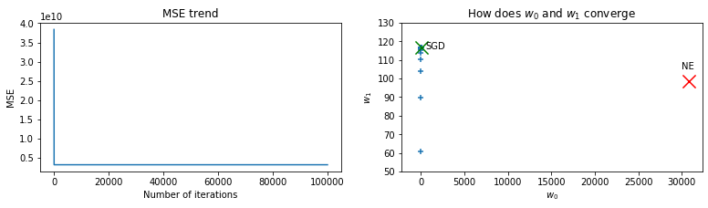

```python
get_gd_plots(j_history, w_0_history, w_1_history)
```

## 這是因為 $w_0$ 與 $w_1$ 的量級（scale）差距太大的緣故

[figure not shown]

```python
get_contour_plot(w_0_history, w_1_history,  -10000, 40000, -200, 200)
```

## 該如何解決這樣的問題？

- 標準化（Standardization）
- 使用進階的梯度遞減演算法
  - 動量梯度遞減
  - 調適梯度遞減
  - RMSprop 梯度遞減
  - Adam 梯度遞減

## 常見的標準化方法有兩個

1. MinMax scaler

$$X_{scaled} = \frac{X-X_{min}}{X_{max} - X_{min}}$$

1. Standard scaler:

$$X_{scaled} = \frac{X-\mu_X}{\sigma_X}$$

## 自己寫 Standard scaler

```python
housing_train = pd.read_csv("https://storage.googleapis.com/kaggle_datasets/House-Prices-Advanced-Regression-Techniques/train.csv")
X = housing_train["GrLivArea"].values.reshape(-1, 1)
y = housing_train["SalePrice"].values
print(X[:5])
```

```
[[1710]
 [1262]
 [1786]
 [1717]
 [2198]]
```

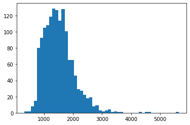

```python
fig = plt.figure()
ax = plt.axes()
ax.hist(X, bins=50)
plt.show()
```

```python
def get_standard_scaled(X):
    X_mu = X.mean(axis=0)
    X_std = X.std(axis=0)
    X_standard_scaled = (X - X_mu)/X_std
    return X_standard_scaled

X_standard_scaled = get_standard_scaled(X)
print(X_standard_scaled[:5])
```

```
[[ 0.37033344]
 [-0.48251191]
 [ 0.51501256]
 [ 0.38365915]
 [ 1.2993257 ]]
```

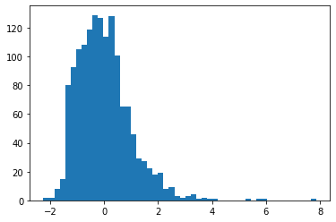

```python
fig = plt.figure()
ax = plt.axes()
ax.hist(X_standard_scaled, bins=50)
plt.show()
```

## 以 `sklearn.preprocessing.StandardScaler()` 做標準化

```python
from sklearn.preprocessing import StandardScaler

ss = StandardScaler()
X_standard_scaled = ss.fit_transform(X.astype(float))
print(X_standard_scaled[:5])
```

```
[[ 0.37033344]
 [-0.48251191]
 [ 0.51501256]
 [ 0.38365915]
 [ 1.2993257 ]]
```

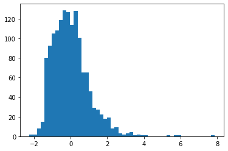

```python
fig = plt.figure()
ax = plt.axes()
ax.hist(X_standard_scaled, bins=50)
plt.show()
```

```python
def gradient_descent(X, y, epochs, learning_rate):
    n = X.shape[1]
    w = np.random.rand(n, 1)
    j_history = []
    w_0_history, w_1_history = [w[0, 0]], [w[1, 0]]
    n_prints = 20
    interval = epochs // n_prints
    for i in range(epochs):
        mse = get_mse(X, y, w)
        j_history.append(mse)
        grad = get_grad(X, y, w)
        w -= learning_rate*grad
        if i % interval == 0:
            print("{} iterations: w_0 = {}; w_1 = {}".format(i, w[0, 0], w[1, 0]))
            w_0_history.append(w[0, 0])
            w_1_history.append(w[1, 0])
    return w, w_0_history, w_1_history, j_history

poly = PolynomialFeatures(1)
X_poly = poly.fit_transform(X_standard_scaled)
X_train, X_validation, y_train, y_validation = train_test_split(X_poly, y, test_size=0.33, random_state=42)
n_epochs = 400000
learning_rate = 0.00001
w, w_0_history, w_1_history, j_history = gradient_descent(X_train, y_train, n_epochs, learning_rate)
```

```
0 iterations: w_0 = 4.4841916805336375; w_1 = 1.3482128926572754
20000 iterations: w_0 = 59626.72837199845; w_1 = 17878.18243392907
40000 iterations: w_0 = 99501.53143987886; w_1 = 29592.00216287277
60000 iterations: w_0 = 126170.67769893567; w_1 = 37263.334811079265
80000 iterations: w_0 = 144008.43128271424; w_1 = 42284.39513306014
100000 iterations: w_0 = 155939.8434054634; w_1 = 45568.82117079792
120000 iterations: w_0 = 163920.97234912566; w_1 = 47715.9051593397
140000 iterations: w_0 = 169259.94571687828; w_1 = 49118.55428379528
160000 iterations: w_0 = 172831.62356648233; w_1 = 50034.23328633572
180000 iterations: w_0 = 175221.12918696355; w_1 = 50631.562876884425
200000 iterations: w_0 = 176819.82277266684; w_1 = 51020.91469200031
220000 iterations: w_0 = 177889.47834468805; w_1 = 51274.489967639056
240000 iterations: w_0 = 178605.20036701515; w_1 = 51439.49050042758
260000 iterations: w_0 = 179084.12441763625; w_1 = 51546.75415093372
280000 iterations: w_0 = 179404.61177586042; w_1 = 51616.413785534074
300000 iterations: w_0 = 179619.08708053632; w_1 = 51661.60364975232
320000 iterations: w_0 = 179762.62477314376; w_1 = 51690.88551787796
340000 iterations: w_0 = 179858.69239641854; w_1 = 51709.83587861957
360000 iterations: w_0 = 179922.99235465357; w_1 = 51722.08362088385
380000 iterations: w_0 = 179966.0318363669; w_1 = 51729.98801419853
```

```python
print(w)
```

```
[[179994.84086141]
 [ 51735.08116123]]
```

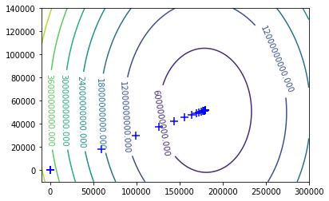

```python
get_contour_plot(w_0_history, w_1_history, -10000, 300000, -10000, 140000)
```

## 逆「標準化」

$$ \hat{y} = X^{scaled}w' = w_0'x_0 + w_1'x_1^{scaled} \\ \hat{y} = w_0'x_0 + w_1'\frac{x_1 - \mu_{x_1}}{\sigma_{x_1}} \\ \hat{y} = w_0' - w_1'\frac{\mu_{x_1}}{\sigma_{x_1}} + \frac{w_1'}{\sigma_{x_1}}x_1 $$$$ w_0 = w_0' - w_1'\frac{\mu_{x_1}}{\sigma_{x_1}} \\ w_1 = \frac{w_1'}{\sigma_{x_1}} $$

```python
X_mu = X.mean(axis=0)
X_std = X.std(axis=0)
w_0 = w[0, 0] - w[1, 0]*X_mu/X_std
w_1 = w[1, 0]/X_std
w_rescaled = np.array([w_0, w_1]).reshape(-1, 1)
print(w_rescaled)
```

```
[[30741.88311311]
 [   98.48665981]]
```

## 除了將 $X$ 標準化，亦可以採用進階梯度遞減演算法，常見的包含

- 動量梯度遞減
- 調適梯度遞減
- RMSProp 梯度遞減
- Adam 梯度遞減
- ...etc.

## 動量梯度遞減（Gradient Descent with Momentum）

> 具有動量的梯度下降在每次迭代更新係數時會將前一次更新的動量（Momentum, $V$）以 $\gamma$ 與當下的梯度加權；這會使得如果當下梯度的正負號與之前相同，更新的幅度會增強；若當下梯度的正負號與之前不一致，更新的幅度則會衰退。

## 每次迭代更新係數時會將前一次更新的動量（Momentum, $V$）以 $\gamma$ 與當下的梯度加權

$$ v_t := \gamma v_{t-1} + (1-\gamma) \nabla J(w) \\ w := w - \alpha v_t \\ \text{where, } \gamma = 0.9 $$

```python
def momentum(X, y, epochs, learning_rate, gamma=0.9):
    n = X.shape[1]
    w = np.random.rand(n, 1)
    j_history = []
    w_0_history, w_1_history = [w[0, 0]], [w[1, 0]]
    n_prints = 20
    interval = epochs // n_prints
    # Initiate velocities
    velocity_values = np.array([0, 0], dtype=float).reshape(-1, 1)
    velocities = {i: velocity_values for i in range(epochs)}
    for i in range(epochs):
        mse = get_mse(X_train, y_train, w)
        j_history.append(mse)
        grad = get_grad(X_train, y_train, w)
        # Use velocities to update w
        if i == 0:
            velocities[i] = (1-gamma) * grad
        else:
            velocities[i] = gamma * velocities[i-1] + (1 - gamma) * grad
        w -= learning_rate*velocities[i]
        if i % interval == 0:
            print("{} iterations: w_0 = {}; w_1 = {}".format(i, w[0, 0], w[1, 0]))
            w_0_history.append(w[0, 0])
            w_1_history.append(w[1, 0])
    return w, w_0_history, w_1_history, j_history
```

```python
housing_train = pd.read_csv("https://storage.googleapis.com/kaggle_datasets/House-Prices-Advanced-Regression-Techniques/train.csv")
X = housing_train["GrLivArea"].values.reshape(-1, 1)
y = housing_train["SalePrice"].values
poly = PolynomialFeatures(1)
X_poly = poly.fit_transform(X)
X_train, X_validation, y_train, y_validation = train_test_split(X_poly, y, test_size=0.33, random_state=42)
n_epochs = 4000000
learning_rate = 0.000005
w, w_0_history, w_1_history, j_history = momentum(X_train, y_train, n_epochs, learning_rate)
```

```
0 iterations: w_0 = 0.5651121845742298; w_1 = 302.8555050167629
200000 iterations: w_0 = 5840.079667523592; w_1 = 113.12849570909785
400000 iterations: w_0 = 10571.743167844725; w_1 = 110.35322778179146
600000 iterations: w_0 = 14405.489080486888; w_1 = 108.10461646949601
800000 iterations: w_0 = 17511.713291423286; w_1 = 106.28271928110773
1000000 iterations: w_0 = 20028.476026478256; w_1 = 104.8065595967253
1200000 iterations: w_0 = 22067.638119884934; w_1 = 103.61052755513438
1400000 iterations: w_0 = 23719.83281637626; w_1 = 102.64146393712201
1600000 iterations: w_0 = 25058.494085110236; w_1 = 101.85629743396882
1800000 iterations: w_0 = 26143.120489139175; w_1 = 101.22013028640922
2000000 iterations: w_0 = 27021.91967739541; w_1 = 100.70468720776574
2200000 iterations: w_0 = 27733.951037145067; w_1 = 100.28705865158982
2400000 iterations: w_0 = 28310.861739888056; w_1 = 99.94868256670257
2600000 iterations: w_0 = 28778.293341575787; w_1 = 99.67451938238366
2800000 iterations: w_0 = 29157.021455333375; w_1 = 99.4523835548445
3000000 iterations: w_0 = 29463.879150944886; w_1 = 99.2724019646871
3200000 iterations: w_0 = 29712.50512281316; w_1 = 99.12657509310701
3400000 iterations: w_0 = 29913.949879684984; w_1 = 99.0084214727508
3600000 iterations: w_0 = 30077.166899074335; w_1 = 98.91268961035799
3800000 iterations: w_0 = 30209.41057636016; w_1 = 98.83512457722844
```

```python
print(w)
```

```
[[30316.55817459]
 [   98.77227918]]
```

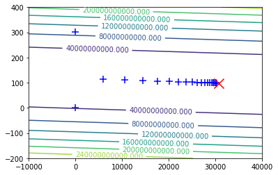

```python
get_contour_plot(w_0_history, w_1_history, -10000, 40000, -200, 400)
```

## 在梯度遞減迭代的過程動態地調整學習速率（Learning rate）的值

$$ ssg = \sum^{t-1} \nabla J^2(w)\\ w := w - \alpha \frac{1}{\epsilon + \sqrt{ssg}} \nabla J(w)\\ \text{where, } \epsilon = 1e^{-8} $$

```python
def adagrad(X, y, epochs, learning_rate, epsilon=1e-8):
    n = X.shape[1]
    w = np.random.rand(n, 1)
    j_history = []
    w_0_history, w_1_history = [w[0, 0]], [w[1, 0]]
    n_prints = 20
    interval = epochs // n_prints
    # Initiate sum of squared gradients
    ssg = np.array([0, 0], dtype=float).reshape(-1, 1)
    for i in range(epochs):
        mse = get_mse(X, y, w)
        j_history.append(mse)
        grad = get_grad(X, y, w)
        # Use adaptive gradient to update w
        ssg += grad**2
        ada_grad = grad / (epsilon + ssg**0.5)
        w -= learning_rate*ada_grad
        if i % interval == 0:
            print("{} iterations: w_0 = {}; w_1 = {}".format(i, w[0, 0], w[1, 0]))
            w_0_history.append(w[0, 0])
            w_1_history.append(w[1, 0])
    return w, w_0_history, w_1_history, j_history
```

```python
housing_train = pd.read_csv("https://storage.googleapis.com/kaggle_datasets/House-Prices-Advanced-Regression-Techniques/train.csv")
X = housing_train["GrLivArea"].values.reshape(-1, 1)
y = housing_train["SalePrice"].values
poly = PolynomialFeatures(1)
X_poly = poly.fit_transform(X)
X_train, X_validation, y_train, y_validation = train_test_split(X_poly, y, test_size=0.33, random_state=42)
n_epochs = 200000
learning_rate = 100
w, w_0_history, w_1_history, j_history = adagrad(X_train, y_train, n_epochs, learning_rate)
```

```
0 iterations: w_0 = 100.41016811063929; w_1 = 100.13841699116087
10000 iterations: w_0 = 10295.68557469965; w_1 = 110.51560794797172
20000 iterations: w_0 = 15643.76530447057; w_1 = 107.37862518013971
30000 iterations: w_0 = 19269.9602061848; w_1 = 105.25166351138056
40000 iterations: w_0 = 21912.027226864928; w_1 = 103.70195494032961
50000 iterations: w_0 = 23900.16752839533; w_1 = 102.53581120449775
60000 iterations: w_0 = 25421.577975286767; w_1 = 101.64342916415478
70000 iterations: w_0 = 26596.815164395117; w_1 = 100.95409533281588
80000 iterations: w_0 = 27509.61363762839; w_1 = 100.41869484705033
90000 iterations: w_0 = 28220.8790336004; w_1 = 100.00150338746839
100000 iterations: w_0 = 28776.188270099883; w_1 = 99.67578779475032
110000 iterations: w_0 = 29210.249596501075; w_1 = 99.42118996393009
120000 iterations: w_0 = 29549.780739018286; w_1 = 99.2220386425142
130000 iterations: w_0 = 29815.485189763585; w_1 = 99.06619022765341
140000 iterations: w_0 = 30023.471462313963; w_1 = 98.94419629790917
150000 iterations: w_0 = 30186.304272821566; w_1 = 98.84868704191862
160000 iterations: w_0 = 30313.799201691098; w_1 = 98.77390514968727
170000 iterations: w_0 = 30413.631418111057; w_1 = 98.7153487657297
180000 iterations: w_0 = 30491.805889015257; w_1 = 98.66949568861382
190000 iterations: w_0 = 30553.02249740392; w_1 = 98.63358921138648
```

```python
print(w)
```

```
[[30600.95624875]
 [   98.60547377]]
```

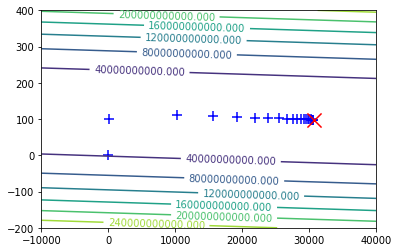

```python
get_contour_plot(w_0_history, w_1_history, -10000, 40000, -200, 400)
```

## RMSProp 梯度遞減（Gradient Descent with Root Mean Square Propagation）

> 和調適梯度遞減同樣是在迭代的過程動態地調整學習速率（Learning rate）的值，但 AdaGrad 所採用的梯度平方和是單調遞增的數值（monotonic increasing），有可能造成學習速率下降過快；RMSProp 利用 $1-\gamma$ 去降低梯度平方和的影響力。

## 利用 $1-\gamma$ 去降低梯度平方和的影響力

$$ ssg = \sum^{t-1} \nabla J^2(w) \\ v_t := \gamma v_{t-1} + (1-\gamma)ssg \\ w := w - \alpha \frac{1}{\epsilon + \sqrt{v_t}} \nabla J(w)\\ \text{where, } \epsilon = 1e^{-8} \text{, }\gamma = 0.9 $$

```python
def RMSProp(X, y, epochs, learning_rate, epsilon=1e-8, gamma=0.9):
    n = X.shape[1]
    w = np.random.rand(n, 1)
    j_history = []
    w_0_history, w_1_history = [w[0, 0]], [w[1, 0]]
    n_prints = 20
    interval = epochs // n_prints
    # Initiate velocities
    velocity_values = np.array([0, 0], dtype=float).reshape(-1, 1)
    velocities = {i: velocity_values for i in range(epochs)}
    # Initiate sum of squared gradients
    ssg = np.array([0, 0], dtype=float).reshape(-1, 1)
    for i in range(epochs):
        mse = get_mse(X, y, w)
        j_history.append(mse)
        grad = get_grad(X, y, w)
        # Use adaptive velocities to update w
        ssg += grad**2
        if i == 0:
            velocities[i] = (1-gamma)*ssg
            ada_grad = grad / (epsilon + velocities[i]**0.5)
        else:
            velocities[i] = gamma * velocities[i-1] + (1-gamma)*ssg
            ada_grad = grad / (epsilon + velocities[i]**0.5)
        w -= learning_rate*ada_grad
        if i % interval == 0:
            print("{} iterations: w_0 = {}; w_1 = {}".format(i, w[0, 0], w[1, 0]))
            w_0_history.append(w[0, 0])
            w_1_history.append(w[1, 0])
    return w, w_0_history, w_1_history, j_history
```

```python
housing_train = pd.read_csv("https://storage.googleapis.com/kaggle_datasets/House-Prices-Advanced-Regression-Techniques/train.csv")
X = housing_train["GrLivArea"].values.reshape(-1, 1)
y = housing_train["SalePrice"].values
poly = PolynomialFeatures(1)
X_poly = poly.fit_transform(X)
X_train, X_validation, y_train, y_validation = train_test_split(X_poly, y, test_size=0.33, random_state=42)
n_epochs = 300000
learning_rate = 100
w, w_0_history, w_1_history, j_history = RMSProp(X_train, y_train, n_epochs, learning_rate)
```

```
0 iterations: w_0 = 316.25963864691033; w_1 = 316.5675099402702
15000 iterations: w_0 = 9507.425114158088; w_1 = 110.97811803545517
30000 iterations: w_0 = 15092.716100738251; w_1 = 107.70195748570922
45000 iterations: w_0 = 18957.69348841872; w_1 = 105.43490859834824
60000 iterations: w_0 = 21777.813264367836; w_1 = 103.78074249952519
75000 iterations: w_0 = 23887.402557346162; w_1 = 102.54334772891985
90000 iterations: w_0 = 25486.239445970492; w_1 = 101.60553986221487
105000 iterations: w_0 = 26706.79865328555; w_1 = 100.88961376435573
120000 iterations: w_0 = 27642.446406221443; w_1 = 100.34080440516513
135000 iterations: w_0 = 28361.41659312709; w_1 = 99.91908859033074
150000 iterations: w_0 = 28914.66767161718; w_1 = 99.59457626104776
165000 iterations: w_0 = 29340.751577356674; w_1 = 99.34465453053531
180000 iterations: w_0 = 29669.059896073304; w_1 = 99.15208359038411
195000 iterations: w_0 = 29922.10355537962; w_1 = 99.00365953017246
210000 iterations: w_0 = 30117.170779924807; w_1 = 98.88924184842374
225000 iterations: w_0 = 30267.560399316964; w_1 = 98.80103004637745
240000 iterations: w_0 = 30383.51232958855; w_1 = 98.73301784788777
255000 iterations: w_0 = 30472.91570085368; w_1 = 98.68057784286718
270000 iterations: w_0 = 30541.850607998862; w_1 = 98.64014372034751
285000 iterations: w_0 = 30595.003888610394; w_1 = 98.6089663916724
```

```python
print(w)
```

```
[[30635.98643298]
 [   98.58492787]]
```

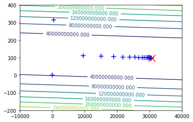

```python
get_contour_plot(w_0_history, w_1_history, -10000, 40000, -200, 400)
```

## Adam 梯度遞減（Gradient Descent with Adaptive Moment Estimation）

> 結合動量梯度遞減與 RMSProp 梯度遞減的特性，是目前最被廣泛使用的梯度遞減演算法。

[figure not shown]

Source: https://wiki.komica.org/

## 結合動量梯度遞減與 RMSProp 梯度遞減的特性

$$ m_t := \beta_1 m_{t-1} + (1-\beta_1)\nabla J(w) \\ v_t := \beta_2 v_{t-1} + (1-\beta_2)\nabla J^2(w) \\ \hat{m_t} = \frac{m_t}{1-\beta_1^t} \\ \hat{v_t} = \frac{v_t}{1-\beta_2^t} \\ w := w - \alpha \frac{\hat{m_t}}{\epsilon + \sqrt{\hat{v_t}}} \\ \text{where, } \epsilon = 1e^{-8} \text{, }\beta_1 = 0.9 \text{, } \beta_2 = 0.999 $$

```python
def adam(X, y, epochs, learning_rate, epsilon=1e-8, beta_1=0.9, beta_2=0.999):
    n = X.shape[1]
    w = np.random.rand(n, 1)
    j_history = []
    w_0_history, w_1_history = [w[0, 0]], [w[1, 0]]
    n_prints = 20
    interval = epochs // n_prints
    # Initiate first and second order moment generation function
    mt_values = np.array([0, 0], dtype=float).reshape(-1, 1)
    mts = {i: mt_values for i in range(epochs)}
    vt_values = np.array([0, 0], dtype=float).reshape(-1, 1)
    vts = {i: vt_values for i in range(epochs)}
    for i in range(epochs):
        mse = get_mse(X, y, w)
        j_history.append(mse)
        grad = get_grad(X, y, w)
        # Use adaptive momentums and velocities to update w
        if i == 0:
            mt = (1-beta_1)*grad
            vt = (1-beta_2)*grad**2
            mts[i] = mt
            vts[i] = vt
            mt_hat = mt / (1-beta_1**(i+1))
            vt_hat = vt / (1-beta_2**(i+1))
            ada_grad = mt_hat / (epsilon + vt_hat**0.5)
        else:
            mt = beta_1*mts[i-1] + (1.0-beta_1)*grad
            vt = beta_2*vts[i-1] + (1.0-beta_2)*grad**2
            mts[i] = mt
            vts[i] = vt
            mt_hat = mt / (1-beta_1**(i+1))
            vt_hat = vt / (1-beta_2**(i+1))
            ada_grad = mt_hat / (epsilon + vt_hat**0.5)
        w -= learning_rate*ada_grad
        if i % interval == 0:
            print("{} iterations: w_0 = {}; w_1 = {}".format(i, w[0, 0], w[1, 0]))
            w_0_history.append(w[0, 0])
            w_1_history.append(w[1, 0])
    return w, w_0_history, w_1_history, j_history
```

```python
import numpy as np
import pandas as pd
from sklearn.model_selection import train_test_split
from sklearn.linear_model import LinearRegression
from sklearn.preprocessing import PolynomialFeatures

housing_train = pd.read_csv("https://storage.googleapis.com/kaggle_datasets/House-Prices-Advanced-Regression-Techniques/train.csv")
X = housing_train["GrLivArea"].values.reshape(-1, 1)
y = housing_train["SalePrice"].values
poly = PolynomialFeatures(1)
X_poly = poly.fit_transform(X)
X_train, X_validation, y_train, y_validation = train_test_split(X_poly, y, test_size=0.33, random_state=42)
n_epochs = 20000
learning_rate = 10
w, w_0_history, w_1_history, j_history = adam(X_train, y_train, n_epochs, learning_rate)
```

```
0 iterations: w_0 = 10.3961355318743; w_1 = 10.59534539359004
1000 iterations: w_0 = 1961.1396874900383; w_1 = 115.40470858422637
2000 iterations: w_0 = 5712.845074768429; w_1 = 113.20399051663033
3000 iterations: w_0 = 10722.692711021731; w_1 = 110.26529645600233
4000 iterations: w_0 = 16291.789463219027; w_1 = 106.99861535886994
5000 iterations: w_0 = 21674.901434946012; w_1 = 103.84108237799094
6000 iterations: w_0 = 26169.315955581642; w_1 = 101.20485853213033
7000 iterations: w_0 = 29165.39133591578; w_1 = 99.44752842864993
8000 iterations: w_0 = 30410.427329716265; w_1 = 98.71723226663376
9000 iterations: w_0 = 30721.063291788865; w_1 = 98.53499443327233
10000 iterations: w_0 = 30768.346412601528; w_1 = 98.50731389725517
11000 iterations: w_0 = 30773.51446758338; w_1 = 98.50417997998501
12000 iterations: w_0 = 30773.9926850671; w_1 = 98.50401109397049
13000 iterations: w_0 = 30774.033943326907; w_1 = 98.50394474014989
14000 iterations: w_0 = 30774.037427003226; w_1 = 98.50395856968514
15000 iterations: w_0 = 30774.037711208308; w_1 = 98.50395412507922
16000 iterations: w_0 = 30774.037734016725; w_1 = 98.50395312798716
17000 iterations: w_0 = 30774.037742513046; w_1 = 98.50395969402082
18000 iterations: w_0 = 30774.258722577877; w_1 = 98.72494383115371
19000 iterations: w_0 = 30774.033770040805; w_1 = 98.49998702159908
```

```python
print(w)
```

```
[[30774.03778808]
 [   98.50400509]]
```

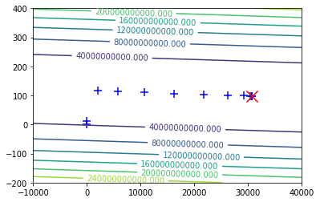

```python
get_contour_plot(w_0_history, w_1_history, -10000, 40000, -200, 400)
```

## 隨堂練習：參考 `gradient_descent()` 函數，在調適、RMSProp 或 Adam 這三個進階梯度演算法中擇一自訂

```python
def gradient_descent(X, y, epochs, learning_rate):
    n = X.shape[1]
    w = np.random.rand(n, 1)
    j_history = []
    w_0_history, w_1_history = [w[0, 0]], [w[1, 0]]
    n_prints = 20
    interval = epochs // n_prints
    for i in range(epochs):
        mse = get_mse(X, y, w)
        j_history.append(mse)
        grad = get_grad(X, y, w)
        w -= learning_rate*grad
        if i % interval == 0:
            print("{} iterations: w_0 = {}; w_1 = {}".format(i, w[0, 0], w[1, 0]))
            w_0_history.append(w[0, 0])
            w_1_history.append(w[1, 0])
    return w, w_0_history, w_1_history, j_history
```

```python
housing_train = pd.read_csv("https://storage.googleapis.com/kaggle_datasets/House-Prices-Advanced-Regression-Techniques/train.csv")
housing_train.corr()["SalePrice"].abs().sort_values()
X = housing_train["GarageArea"].values.reshape(-1, 1)
y = housing_train["SalePrice"].values
X_train, X_validation, y_train, y_validation = train_test_split(X, y, test_size=0.33, random_state=42)
lr = LinearRegression()
lr.fit(X_train, y_train)
w = lr.coef_.copy()
w = np.insert(w, 0, lr.intercept_).reshape(-1, 1)
print(w)
```

```
[[72754.55457258]
 [  226.93274858]]
```

```python
poly = PolynomialFeatures(1)
X_poly = poly.fit_transform(X)
X_train, X_validation, y_train, y_validation = train_test_split(X_poly, y, test_size=0.33, random_state=42)
n_epochs = 100000
learning_rate = 1
w, w_0_history, w_1_history, j_history = adam(X_train, y_train, n_epochs, learning_rate)
```

```
0 iterations: w_0 = 1.5367579328660468; w_1 = 1.8517318822677336
5000 iterations: w_0 = 2639.4744827717514; w_1 = 350.04556640453876
10000 iterations: w_0 = 7439.713441032184; w_1 = 341.6020073548833
15000 iterations: w_0 = 12361.83272001707; w_1 = 332.95916058582645
20000 iterations: w_0 = 17278.461791253652; w_1 = 324.32731120378855
25000 iterations: w_0 = 22187.556449443287; w_1 = 315.7088998683678
30000 iterations: w_0 = 27087.642446162037; w_1 = 307.00699039377025
35000 iterations: w_0 = 31976.760779832854; w_1 = 298.52283918828317
40000 iterations: w_0 = 36852.24015224437; w_1 = 289.9635446864961
45000 iterations: w_0 = 41710.310152927676; w_1 = 281.43448781892823
50000 iterations: w_0 = 46545.406493714836; w_1 = 272.945937206522
55000 iterations: w_0 = 51348.834354630686; w_1 = 264.5129636221826
60000 iterations: w_0 = 56105.91788201499; w_1 = 256.1613646248887
65000 iterations: w_0 = 60789.015534173246; w_1 = 247.93965268750193
70000 iterations: w_0 = 65336.5094642213; w_1 = 239.95600827496688
75000 iterations: w_0 = 69564.36439924658; w_1 = 232.53354194127266
80000 iterations: w_0 = 72531.6442158034; w_1 = 227.32410574853196
85000 iterations: w_0 = 72754.55598297447; w_1 = 226.93469487272293
90000 iterations: w_0 = 72754.55462443343; w_1 = 226.93280054940092
95000 iterations: w_0 = 72754.55567058029; w_1 = 226.93384659282427
```

```python
print(w)
```

```
[[72754.55457258]
 [  226.93274858]]
```

## 延伸閱讀

[An overview of gradient descent optimization algorithms](http://ruder.io/optimizing-gradient-descent/index.html?source=post_page---------------------------#adam)